# Spillovers to High-Income Countries — LMIC-origin vs HIC-origin innovations

Innovation Strategy Explorer — insights

2026-04-22

## What this note shows

How much per-innovation spillover value do different technologies generate **for High-Income Countries (HICs)** — and does this depend on where the innovation was filed and on whether we restrict to *granted* families? The faceted grouped bar chart below compares three populations of innovations, all scored on the *same* destination flow (*Average Spillovers to HICs* = `ev_hic`):

- **LMIC-origin** innovations, excluding China
- **China-origin** innovations
- **HIC-origin** innovations

It shows each origin group twice — once restricted to *granted* patent families (the app’s default) and once including *all* families regardless of grant status. Technologies are on the x-axis.

## Data source

Six downloads from the public Country Explorer tab of https://mondpanther-iseapp2.share.connect.posit.cloud/, with **Value flow = *Average Spillovers to HICs*** in all six cases. Three origins × two grant statuses. Click any “open in app” link below to jump directly to the bookmarked view used for that row:

| File in `insights/data/` | `country-country` filter | Granted only? | App view |
| --- | --- | --- | --- |
| `flow_LMIC_to_HIC_granted.csv` | `LMICs (excl. China)` | yes | open in app |
| `flow_China_to_HIC_granted.csv` | `CN` (China) | yes | open in app |
| `flow_HIC_to_HIC_granted.csv` | `High income countries` | yes | open in app |
| `flow_LMIC_to_HIC_all.csv` | `LMICs (excl. China)` | **no** | open in app |
| `flow_China_to_HIC_all.csv` | `CN` (China) | **no** | open in app |
| `flow_HIC_to_HIC_all.csv` | `High income countries` | **no** | open in app |

## Figure — average spillover value to HICs per innovation, by technology and origin

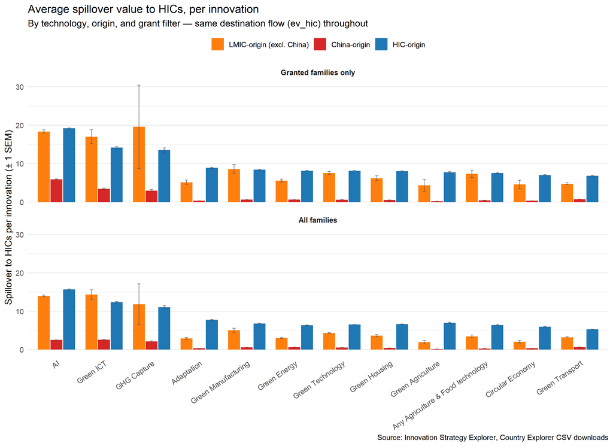

## Reading the chart

- Within each technology group: **orange** = LMIC-origin (excl. China), **red** = China-origin, **blue** = HIC-origin — all measuring the average downstream spillover value per innovation that accrues to HICs.
- Error bars are $\pm$ one standard error of the mean.
- Technologies are sorted (consistently across both facets) by HIC-origin magnitude in the *Granted families only* panel.
- The top facet keeps only **granted** families (the app’s default). The bottom facet uses **all** families regardless of grant status — so it includes pending or abandoned applications. Differences between the facets show how much of the gap between origins is driven by grant selectivity versus by innovation quality itself.

China sits between the two comparison groups analytically: it’s the world’s largest patent-filer and accounts for the bulk of LMIC innovation volume, but its patents typically face weaker examiner citation links into HIC markets than HIC-origin patents do. Seeing where the red bar tracks orange (weak HIC absorption, like the broader LMIC pool) versus where it tracks or exceeds blue (HIC-comparable absorption) helps identify technology fields where Chinese innovation has already crossed into the HIC citation mainstream. Moving from the *Granted* facet to the *All families* facet typically shrinks HIC-origin and LMIC-origin averages unevenly — a useful test for how sensitive the ordering is to grant selection.

## Summary table

Per-innovation HIC-spillover means by technology, origin, and grant filter.

| Technology | Grant filter | Mean LMIC→HIC | Mean China→HIC | Mean HIC→HIC | N LMIC-origin | N China-origin | N HIC-origin |
| --- | --- | --- | --- | --- | --- | --- | --- |
| AI | Granted families only | 18.37 | 5.92 | 19.24 | 10604 | 93629 | 197453 |
| Green ICT | Granted families only | 17.00 | 3.45 | 14.20 | 928 | 12639 | 15500 |
| GHG Capture | Granted families only | 19.58 | 2.96 | 13.54 | 78 | 1463 | 2559 |
| Adaptation | Granted families only | 5.15 | 0.34 | 8.90 | 971 | 91273 | 26082 |
| Green Manufacturing | Granted families only | 8.56 | 0.61 | 8.40 | 898 | 94726 | 39307 |
| Green Energy | Granted families only | 5.59 | 0.64 | 8.15 | 2118 | 229232 | 113544 |
| Green Technology | Granted families only | 7.57 | 0.60 | 8.13 | 6511 | 558375 | 265940 |
| Green Housing | Granted families only | 6.21 | 0.51 | 8.03 | 688 | 66552 | 27778 |
| Green Agriculture | Granted families only | 4.37 | 0.18 | 7.74 | 110 | 21716 | 4477 |
| Any Agriculture & Food technology | Granted families only | 7.33 | 0.44 | 7.53 | 1545 | 91214 | 57555 |
| Circular Economy | Granted families only | 4.60 | 0.32 | 7.00 | 519 | 46162 | 14452 |
| Green Transport | Granted families only | 4.76 | 0.73 | 6.83 | 813 | 48093 | 61034 |
| AI | All families | 13.97 | 2.53 | 15.72 | 22110 | 405479 | 365766 |
| Green ICT | All families | 14.35 | 2.59 | 12.39 | 1447 | 26156 | 23727 |
| GHG Capture | All families | 11.82 | 2.16 | 11.07 | 160 | 2969 | 4230 |
| Adaptation | All families | 2.94 | 0.34 | 7.74 | 2978 | 148900 | 42728 |
| Green Agriculture | All families | 1.98 | 0.16 | 6.98 | 390 | 49182 | 7322 |
| Green Manufacturing | All families | 5.07 | 0.60 | 6.82 | 2089 | 153608 | 68202 |
| Green Housing | All families | 3.65 | 0.45 | 6.64 | 1586 | 98755 | 43386 |
| Green Technology | All families | 4.32 | 0.57 | 6.55 | 16501 | 918513 | 462442 |
| Any Agriculture & Food technology | All families | 3.45 | 0.28 | 6.42 | 5379 | 286386 | 95896 |
| Green Energy | All families | 3.03 | 0.63 | 6.36 | 5790 | 365287 | 206884 |
| Circular Economy | All families | 2.05 | 0.34 | 5.97 | 1726 | 78392 | 23281 |
| Green Transport | All families | 3.22 | 0.66 | 5.28 | 1904 | 77519 | 108112 |

## Notes & caveats

- All six bars use the same destination flow `ev_hic` — *Average Spillovers to HICs* — so the levels are directly comparable within a technology facet.
- The sample size column `innos` is **not** the same across origins: LMIC innovator pools are smaller, so their SEMs are typically larger. Treat any orange/blue gap inside a large SEM with caution.
- Grant rates differ by origin (HIC applicants are granted at higher rates than LMIC applicants on average). Mean changes between the *Granted only* and *All families* facets therefore mix two effects — average innovation quality in the population and the selectivity of the grant filter. Use the two panels together, not in isolation.
- The origin-country filter selects patents filed from the relevant country group; downstream-citing patents can come from anywhere in the world, but only HIC-located citations count toward `ev_hic`.
- Data acquisition uses only the app’s public CSV-download endpoint (via `chromote`) — the patent database is never accessed directly.